# Statistical Learning - Semana 1

Ángel Escalante

3/2/2020

## Semana 1

### Selección de modelo y trade-off de varianza y sesgo

Para visualizar uno de los temas platicados en los videos de la primera clase, usaré un ejemplo básico con datos simulados de una función de costo $y=500+0.4(q-10)^{3}$, donde $q$ es la cantidad de producto producido y $y$ es el costo asociado a la producción. Esto nos creará una línea perfecta como se aprecia abajo:

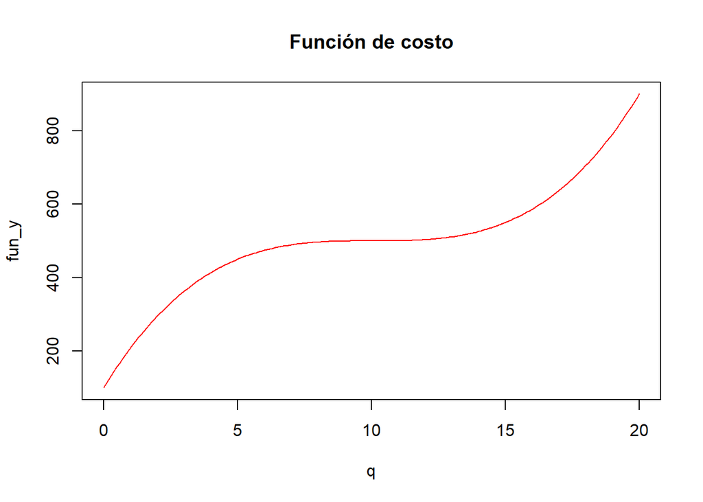

```r
# Cargando paquetes del tidyverse
suppressPackageStartupMessages(library(tidyverse))

# Datos para gráfica
q <- seq(0, 20, 0.1)
fun_y <- 500 + 0.4 * (q - 10) ^ 3

# Gráfica
plot(q, fun_y, type = 'l', col = 'red', main = 'Función de costo')
```

Sin embargo, sabemos que las observaciones de fenómenos aleatorios siempre tienen un error asociado, y lo que me interesa es simular datos que puedan provenir de esas observaciones. Por tanto, añadiré un término de error
$$\epsilon \sim N(\mu = 10, \sigma = 80)$$
Así, simulariamos valores de la siguiente variable $Y=500+0.4(q-10)^{3} + \epsilon$

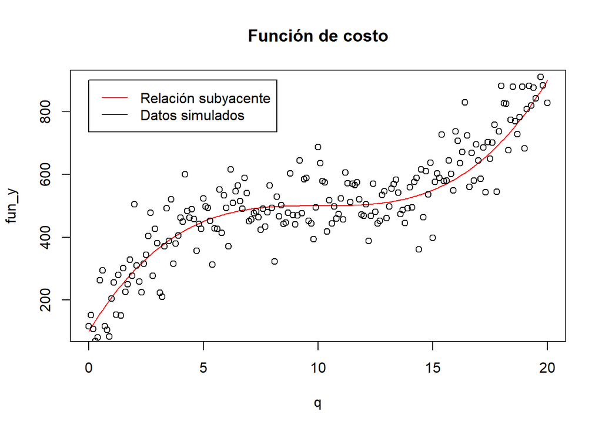

```r
# Creando término de error proveniente de una normal
set.seed(69) # Semilla con número mágico
error <- rnorm(length(q), mean = 10, sd = 80)
fun_y_error <- fun_y + error

# Gráfica de datos simulados
plot(q, fun_y, col = 'red', type = 'l', main = 'Función de costo')
points(q, fun_y_error)
legend(0, 900,
       legend = c('Relación subyacente', 'Datos simulados'),
       col = c('red', 'black'),
       lty = 1)
```

Ajustamos un modelo lineal simple y dos modelos polinómicos de grado $N=3$ y $N=26$, es decir,
$$\hat{Y}=\hat{\beta}_{0}+\hat{\beta}_{1}q$$
$$\hat{Y}=\hat{\beta}_{0}+\hat{\beta}_{1}q+\hat{\beta}_{2}q^{2}+\hat{\beta}_{3}q^{3}$$
$$\hat{Y}=\hat{\beta}_{0}+\hat{\beta}_{1}q+\hat{\beta}_{2}q^{2}+...+\hat{\beta}_{26}q^{26}$$

```r
# Creando un data.frame
df <- data_frame(y = fun_y_error, q = q)

mod1 <- lm(y ~ q, data = df)
mod2 <- lm(y ~ poly(q, 3), data = df)
mod3 <- lm(y ~ poly(q, 26), data = df)

summary(mod1)
```

```
##
## Call:
## lm(formula = y ~ q, data = df)
##
## Residuals:
##      Min       1Q   Median       3Q      Max
## -264.507  -61.814   -3.836   64.440  276.220
##
## Coefficients:
##             Estimate Std. Error t value Pr(>|t|)
## (Intercept)  252.304     13.942   18.10   <2e-16 ***
## q             25.951      1.206   21.52   <2e-16 ***
## ---
## Signif. codes:  0 '***' 0.001 '**' 0.01 '*' 0.05 '.' 0.1 ' ' 1
##
## Residual standard error: 99.2 on 199 degrees of freedom
## Multiple R-squared:  0.6995, Adjusted R-squared:  0.6979
## F-statistic: 463.1 on 1 and 199 DF,  p-value: < 2.2e-16
```

```r
summary(mod2)
```

```
##
## Call:
## lm(formula = y ~ poly(q, 3), data = df)
##
## Residuals:
##      Min       1Q   Median       3Q      Max
## -185.583  -46.021   -2.942   50.521  207.393
##
## Coefficients:
##             Estimate Std. Error t value Pr(>|t|)
## (Intercept)  511.818      5.289  96.779   <2e-16 ***
## poly(q, 3)1 2134.810     74.978  28.472   <2e-16 ***
## poly(q, 3)2   65.066     74.978   0.868    0.387
## poly(q, 3)3  920.076     74.978  12.271   <2e-16 ***
## ---
## Signif. codes:  0 '***' 0.001 '**' 0.01 '*' 0.05 '.' 0.1 ' ' 1
##
## Residual standard error: 74.98 on 197 degrees of freedom
## Multiple R-squared:   0.83,  Adjusted R-squared:  0.8274
## F-statistic: 320.7 on 3 and 197 DF,  p-value: < 2.2e-16
```

```r
summary(mod3)
```

```
##
## Call:
## lm(formula = y ~ poly(q, 26), data = df)
##
## Residuals:
##      Min       1Q   Median       3Q      Max
## -180.734  -44.380   -4.409   52.040  175.466
##
## Coefficients:
##               Estimate Std. Error t value Pr(>|t|)
## (Intercept)    511.818      5.235  97.772   <2e-16 ***
## poly(q, 26)1  2134.810     74.216  28.765   <2e-16 ***
## poly(q, 26)2    65.066     74.216   0.877   0.3819
## poly(q, 26)3   920.076     74.216  12.397   <2e-16 ***
## poly(q, 26)4   -58.741     74.216  -0.791   0.4297
## poly(q, 26)5   -24.186     74.216  -0.326   0.7449
## poly(q, 26)6    20.737     74.216   0.279   0.7803
## poly(q, 26)7   -12.630     74.216  -0.170   0.8651
## poly(q, 26)8    94.117     74.216   1.268   0.2064
## poly(q, 26)9     2.193     74.216   0.030   0.9765
## poly(q, 26)10  -93.130     74.216  -1.255   0.2112
## poly(q, 26)11 -121.198     74.216  -1.633   0.1043
## poly(q, 26)12   36.004     74.216   0.485   0.6282
## poly(q, 26)13   46.126     74.216   0.622   0.5351
## poly(q, 26)14  -42.327     74.216  -0.570   0.5692
## poly(q, 26)15  -45.023     74.216  -0.607   0.5449
## poly(q, 26)16  -92.005     74.216  -1.240   0.2168
## poly(q, 26)17  -97.427     74.216  -1.313   0.1910
## poly(q, 26)18 -151.253     74.216  -2.038   0.0431 *
## poly(q, 26)19  -55.328     74.216  -0.745   0.4570
## poly(q, 26)20  163.333     74.216   2.201   0.0291 *
## poly(q, 26)21  -33.351     74.216  -0.449   0.6537
## poly(q, 26)22   67.856     74.216   0.914   0.3618
## poly(q, 26)23   65.983     74.216   0.889   0.3752
## poly(q, 26)24 -130.675     74.216  -1.761   0.0800 .
## poly(q, 26)25  -85.207     74.216  -1.148   0.2525
## poly(q, 26)26    2.960     74.216   0.040   0.9682
## ---
## Signif. codes:  0 '***' 0.001 '**' 0.01 '*' 0.05 '.' 0.1 ' ' 1
##
## Residual standard error: 74.22 on 174 degrees of freedom
## Multiple R-squared:  0.8529, Adjusted R-squared:  0.8309
## F-statistic: 38.81 on 26 and 174 DF,  p-value: < 2.2e-16
```

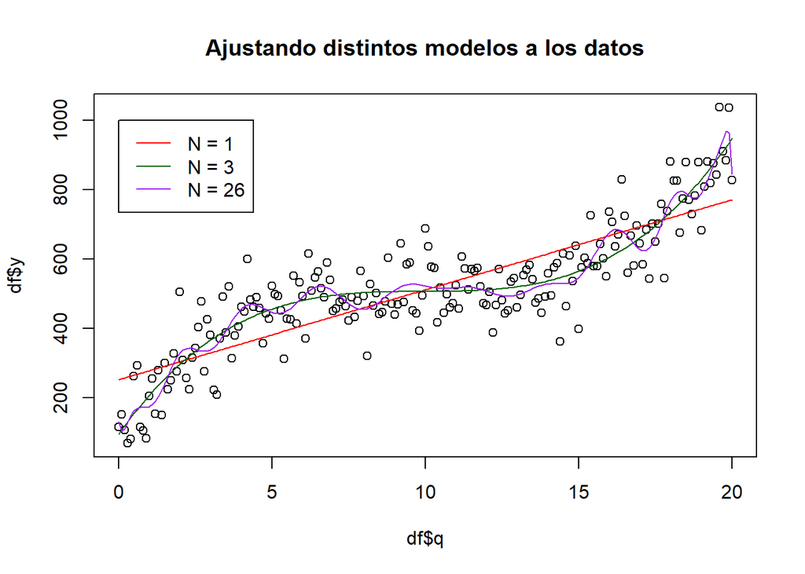

```r
plot(df$q, df$y, main = 'Ajustando distintos modelos a los datos')
lines(q, predict(mod1, newdata = df), col = 'red')
lines(q, predict(mod2, newdata = df), col = 'darkgreen')
lines(q, predict(mod3, newdata = df), col = 'purple')

legend(0, 1000,
       legend = c('N = 1', 'N = 3', 'N = 26'),
       col = c('red', 'darkgreen', 'purple'),
       lty = 1)
```

Regresando al enfoque de Statistical Learning, una forma de medir la eficiencia de estos modelos para predecir nuevos datos, deberíamos dividir el conjunto de datos en dos, un conjunto de entrenamiento ($Tr =\{x_{i}, y_{i}\}_{i}^{N}$) y uno de prueba ($Te = \{x_{i}, y_{i}\}_{i}^{M}$) y definir una medida de error para el testing; el error cuadrático medio $MSE = Average_{i \in Te}$, esto es, el promedio del error entre la predicción y el valor real elevado al cuadrado.

Definamos la función de MSE (Mean Square Error) en R!

```r
# Creando función de MSE
mse <- function(x, y){
  if(length(x) != length(y)) stop('¡Los vectores deben ser de la misma longitud!')
  sum((x - y) ^ 2)/ length(x)
}
```

Ahora creamos los conjuntos de datos de train y testing:

```r
# Dividimos 80% de datos de entrenamiento y 20% de testing
train_rows <- sample(1:nrow(df), round(0.8 * nrow(df), 0))
train <- df[train_rows, ]
test <- df[-train_rows, ]

# Ajustamos al conjunto de datos de entrenamiento los 3 modelos
mod_train1 <- lm(y ~ q, data = train)
mod_train2 <- lm(y ~ poly(q, 3), data = train)
mod_train3 <- lm(y ~ poly(q, 26), data = train)
```

Se ajusta el modelo de regresión a cada conjunto de datos y después se mide el Mean Squared Error:

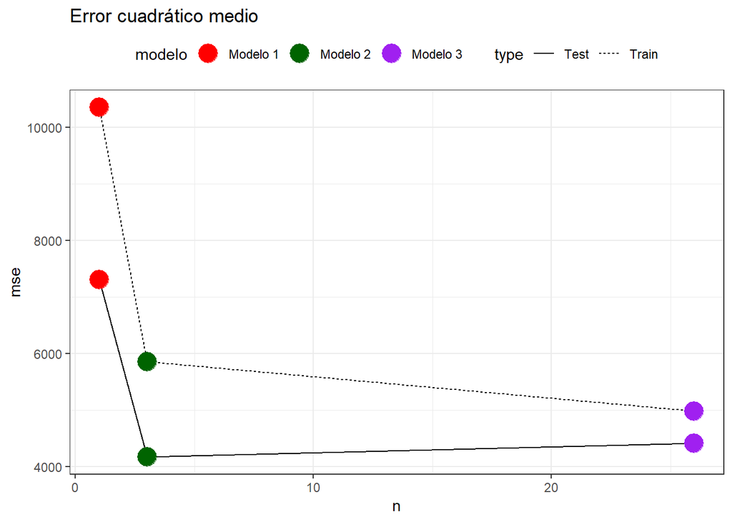

```r
# Hacemos predicción sobre los datos de testing para los 3 modelos sobre los datos de entrenamiento
t1 <- mse(train$y, predict(mod_train1, newdata = train))
t2 <- mse(train$y, predict(mod_train2, newdata = train))
t3 <- mse(train$y, predict(mod_train3, newdata = train))

# Hacemos predicción sobre los datos de testing para los 3 modelos sobre los datos de entrenamiento
te1 <- mse(test$y, predict(mod_train1, newdata = test))
te2 <- mse(test$y, predict(mod_train2, newdata = test))
te3 <- mse(test$y, predict(mod_train3, newdata = test))

df_final <- data_frame(type = c(rep('Train', 3), rep('Test', 3)),
                       modelo = rep(c('Modelo 1', 'Modelo 2', 'Modelo 3'), 2),
                          n = rep(c(1, 3, 26), 2),
                          mse = c(t1, t2, t3, te1, te2, te3))

theme_set(theme_bw())
ggplot(df_final, aes(x = n, y = mse, group = type)) +
  geom_line(aes(linetype = type)) + geom_point(aes(color = modelo), size = 6) +
  theme(legend.position = "top") + labs(title = 'Error cuadrático medio') +
  scale_color_manual(values = c('red', 'darkgreen', 'purple'))
```